# Ex4

Shaqed Carasso

ID: 201281805

22/11/2021

## Functional enrichment analysis

1. Re-run gProfileR, this time using pathway annotations such as KEGG, REACTOME, and protein complex databases such as CORUM, in addition to the GO terms. Sort the resulting tables by columns `precision` and/or `recall`. How do the top GO terms change when sorted for `precision`, `recall`, or `p.value`? hint: use `order()` for sorting.

*It changes the top terms, although all of them still pass by p-values of less than 0.05.* *By looking at the top precision we can see that 20% of the genes in the input list were annotated to Metabolic pathways* *Looking at recall we can see the top terms in which the input list contains most of the genes of those terms.* *By p-value, we look at the top terms that were identified in the input, after correction.*

```r
KEGGResults <- gprofiler(query = genesOfInterest,
                       organism = 'hsapiens',
                       src_filter = 'KEGG',
                       hier_filtering = 'moderate')
```

sorted by precision: The proportion of genes in the input list that are annotated to the function.

```r
KEGGResults %>%
        arrange(desc(precision)) %>%
        select(term.name, p.value, precision, recall) %>%
        head()
```

```
##                                 term.name  p.value precision recall
## 1                      Metabolic pathways 4.40e-02     0.207  0.282
## 2 Neuroactive ligand-receptor interaction 1.27e-10     0.068  0.435
## 3  Cytokine-cytokine receptor interaction 6.78e-06     0.063  0.384
## 4               Calcium signaling pathway 9.71e-04     0.040  0.390
## 5     Complement and coagulation cascades 1.84e-26     0.037  0.835
## 6          Cell adhesion molecules (CAMs) 1.04e-04     0.034  0.430
```

sorted by recall: The proportion of functionally annotated genes that the query recovers

```r
KEGGResults %>%
        arrange(desc(recall)) %>%
        select(term.name, p.value, precision, recall) %>%
        head()
```

```
##                                  term.name  p.value precision recall
## 1      Complement and coagulation cascades 1.84e-26     0.037  0.835
## 2                      Nitrogen metabolism 9.91e-03     0.007  0.706
## 3          Staphylococcus aureus infection 5.74e-08     0.019  0.654
## 4 Glycine, serine and threonine metabolism 8.02e-06     0.015  0.650
## 5                           Bile secretion 4.30e-10     0.025  0.634
## 6                    Arginine biosynthesis 3.68e-02     0.007  0.619
```

```r
KEGGResults %>%
        arrange(p.value) %>%
        select(term.name, p.value, precision, recall) %>%
        head()
```

```
##                                 term.name  p.value precision recall
## 1     Complement and coagulation cascades 1.84e-26     0.037  0.835
## 2 Neuroactive ligand-receptor interaction 1.27e-10     0.068  0.435
## 3                          Bile secretion 4.30e-10     0.025  0.634
## 4         Staphylococcus aureus infection 5.74e-08     0.019  0.654
## 5                 Chemical carcinogenesis 8.54e-07     0.025  0.543
## 6  Cytokine-cytokine receptor interaction 6.78e-06     0.063  0.384
```

## Gene set enrichment analysis

We use the bioconductor package gage to demonstrate how to do GSEA using normalized expression data of the samples as input.

```r
#Let's define the first gene set as the list of genes from one of the
#significant GO terms found in the GO analysis. order go results by pvalue
goResults <- goResults[order(goResults$p.value),]

#restrict the terms that have at most 100 genes overlapping with the query
go <- goResults[goResults$overlap.size < 100,]

geneSet1 <- unlist(strsplit(go[1,]$intersection, ','))

#Define another gene set by just randomly selecting 25 genes from the counts
#table get normalized counts from DESeq2 results
normalizedCounts <- DESeq2::counts(dds, normalized = TRUE)

geneSet2 <- sample(rownames(normalizedCounts), 25)

geneSets <- list('top_GO_term' = geneSet1,
                 'random_set' = geneSet2)

#Use the normalized counts to carry out a GSEA.
gseaResults <- gage(exprs = log2(normalizedCounts+1),
                    ref = match(rownames(colData[colData$group =='CTRL',]),
                                colnames(normalizedCounts)),
                    samp = match(rownames(colData[colData$group == 'CASE',]),
                                 colnames(normalizedCounts)),
                    gsets = geneSets, compare = 'as.group')
```

2. Repeat the gene set enrichment analysis by trying different options for the `compare` argument of the `GAGE:gage` function. How do the results differ?

*I’ve changed it to ‘paired’, and now I got the results for each case seperatly rather than a group against group comparison.*

```r
gseaResults <- gage(exprs = log2(normalizedCounts+1),
                    ref = match(rownames(colData[colData$group =='CTRL',]),
                                colnames(normalizedCounts)),
                    samp = match(rownames(colData[colData$group == 'CASE',]),
                                 colnames(normalizedCounts)),
                    gsets = geneSets, compare = 'paired')
```

3. Make a scatter plot of GO term sizes and obtained p-values by setting the `gProfiler::gprofiler` argument `significant = FALSE`. Is there a correlation of term sizes and p-values? (Hint: Take -log10 of p-values). If so, how can this bias be mitigated?

*There seems to be a negative correlation between term size and p-values, meaning that larger term sizes produce more significant results.* *It would make sense to account in some way the term sizes. maybe by normalizing the identified genes to term size ratio.*

```r
goResults_all <- gprofiler(query = genesOfInterest,
                       organism = 'hsapiens',
                       significant = F,
                       src_filter = 'GO',
                       hier_filtering = 'none'
                       )
```

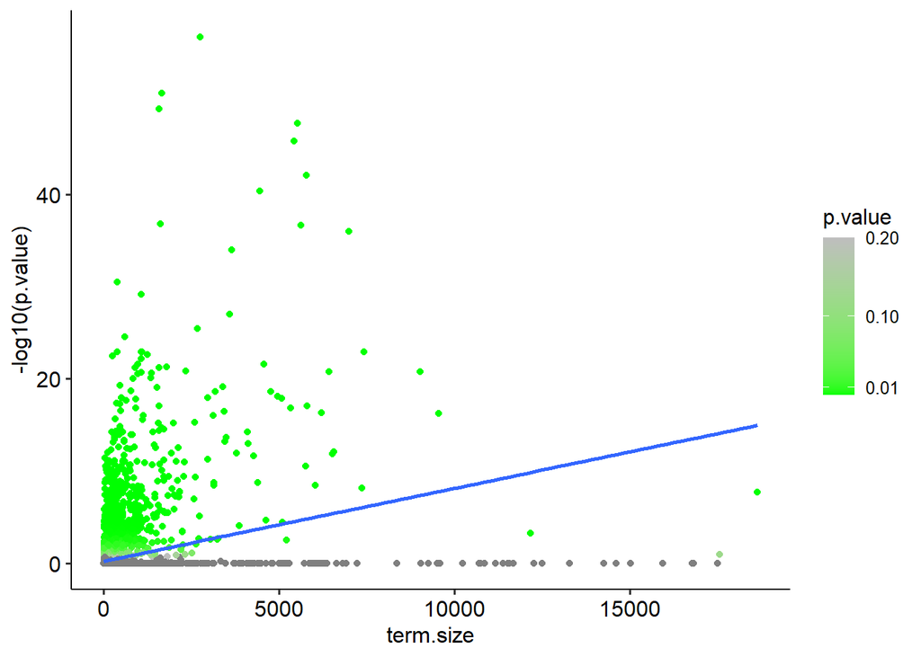

```r
ggplot(goResults_all, aes(x = term.size, y = -log10(p.value))) +
        geom_point(aes(color = p.value))+
        scale_colour_gradient(low = "green", high="gray", breaks = c(0.01,0.1,0.2), limits = c(0,0.2))+
        geom_smooth(method = "lm", se = F)+
        theme_pubr(legend = "right")
```

4. Do a gene-set enrichment analysis using gene sets from top 10 GO terms.

```r
goResults <- goResults[order(goResults$p.value),]

go <- goResults[goResults$overlap.size < 100,]

#Define another gene set by just randomly selecting 25 genes from the counts
#table get normalized counts from DESeq2 results
normalizedCounts <- DESeq2::counts(dds, normalized = TRUE)

# extracting the terms of top 10 to a list
geneSets10 <- list()

for(i in seq(1,10)) {
    termname = go$term.name[i]
    geneset <- unlist(strsplit(go[i,]$intersection, ','))
    geneSets10[[termname]] <- geneset
}


# Using the defined gene sets, we’d like to do a group comparison between the case
# samples with respect to the control samples.

#Use the normalized counts to carry out a GSEA.
gseaResults <- gage(exprs = log2(normalizedCounts+1),
                    ref = match(rownames(colData[colData$group =='CTRL',]),
                                colnames(normalizedCounts)),
                    samp = match(rownames(colData[colData$group == 'CASE',]),
                                 colnames(normalizedCounts)),
                    gsets = geneSets10, compare = 'as.group')
```

5. What are the other available R packages that can carry out gene set enrichment analysis for RNA-seq datasets?

*Packages: clusterProfiler, Enrichr, hypeR, topGO.*

6. Use the topGO package (https://bioconductor.org/packages/release/bioc/html/topGO.html) to re-do the GO term analysis. Compare and contrast the results with what has been obtained using the `gProfileR` package. Which tool is faster, `gProfileR` or topGO? Why?

*The results are very different. Only 13 GO terms appeared in both. `gProfileR` worked faster, because it didn’t need to download all the GO ENSEMBL database.*

```r
library(topGO)
library(GO.db)
library(biomaRt)



allgenes <- rownames(DEresults)

#adapted from https://datacatz.wordpress.com/2018/01/19/gene-set-enrichment-analysis-with-topgo-part-1/

# create GO db for genes to be used using biomaRt - please note that this takes a while
db= useMart('ENSEMBL_MART_ENSEMBL',dataset='hsapiens_gene_ensembl', host="www.ensembl.org")
go_ids= getBM(attributes=c('go_id', 'external_gene_name', 'namespace_1003'), filters='external_gene_name', values=allgenes, mart=db)

# build the gene 2 GO annotation list (needed to create topGO object)
gene_2_GO=unstack(go_ids[,c(1,2)])

# remove any candidate genes without GO annotation
keep = genesOfInterest %in% go_ids[,2]
keep =which(keep==TRUE)
genesOfInterest=genesOfInterest[keep]


# make named factor showing which genes are of interest
geneList=factor(as.integer(allgenes %in% genesOfInterest))
names(geneList)= allgenes

sampleGOdata <- new("topGOdata",
                    description = "Simple session", ontology = "BP",
                    allGenes = geneList,
                    #geneSel = t(genesOfInterest),
                    nodeSize = 10,
                    annot = annFUN.gene2GO, gene2GO = gene_2_GO)


# define test using the weight01 algorithm (default) with fisher
weight_fisher_result=runTest(sampleGOdata, algorithm='weight01', statistic='fisher')

# generate a table of results: we can use the GenTable function to generate a summary table with the results from tests applied to the topGOdata object.
allGO=usedGO(sampleGOdata)
all_res=GenTable(sampleGOdata, weightFisher=weight_fisher_result, orderBy='weightFisher', topNodes=length(allGO))

#performing BH correction on our p values
p.adj=round(p.adjust(all_res$weightFisher,method="BH"),digits = 4)

# create the file with all the statistics from GO analysis
all_res_final=cbind(all_res,p.adj)
all_res_final=all_res_final[order(all_res_final$p.adj),]

#get list of significant GO before multiple testing correction
results.table.p= all_res_final[which(all_res_final$weightFisher<=0.001),]

#get list of significant GO after multiple testing correction
results.table.bh=all_res_final[which(all_res_final$p.adj<=0.05),]

#number of genes that appear in both
sum( goResults$term.name %in% results.table.bh$Term)
```

```
## [1] 13
```

```r
head(results.table.bh$Term, n = 10)
```

```
##  [1] "regulation of complement activation"
##  [2] "complement activation, classical pathway"
##  [3] "oxidation-reduction process"
##  [4] "cell-cell signaling"
##  [5] "acute-phase response"
##  [6] "cell adhesion"
##  [7] "xenobiotic metabolic process"
##  [8] "complement activation, alternative pathw..."
##  [9] "extracellular matrix organization"
## [10] "cholesterol homeostasis"
```

```r
head(goResults$term.name, n = 10)
```

```
##  [1] "plasma membrane part"
##  [2] "ion transport"
##  [3] "regulation of biological quality"
##  [4] "multicellular organismal process"
##  [5] "extracellular structure organization"
##  [6] "transmembrane transporter activity"
##  [7] "organic acid metabolic process"
##  [8] "response to drug"
##  [9] "biological adhesion"
## [10] "system development"
```

7. Given a gene set annotated for human, how can it be utilized to work on *C. elegans* data? (Hint: See `biomaRt::getLDS`).

*Change the dataset argument in the useMart function to ‘celegans_gene_ensembl’*

8. Import curated pathway gene sets with Entrez identifiers from the [MSIGDB database](http://software.broadinstitute.org/gsea/msigdb/collections.jsp) and re-do the GSEA for all curated gene sets.

```r
library(msigdbr)
cgp_gene_sets = msigdbr(species = "Homo sapiens", category = "C2")

msigdbr_list = split(x = cgp_gene_sets$gene_symbol, f = cgp_gene_sets$gs_name)

gseaResults_cgp <- gage(exprs = log2(normalizedCounts+1),
                    ref = match(rownames(colData[colData$group =='CTRL',]),
                                colnames(normalizedCounts)),
                    samp = match(rownames(colData[colData$group == 'CASE',]),
                                 colnames(normalizedCounts)),
                    gsets = msigdbr_list, compare = 'as.group')
```